# A Quick Intro for R Beginners

Mohamed Fergany Omran

mohamed.fergany.omran@gmail.com

2/28/2022

## Hi everyone,

This notebook is a summarization of the [Google Introductory Course to R Programming](https://www.coursera.org/learn/data-analysis-r/home/welcome) the seventh course of the Google Data Analytics Certificate.  
Personally I highly recommend to take that course if you wanna start learning R.

It covers its contents and as you go through the notebook you’ll find more resources attached in the markdown. During my enrollment, I’ve made this notebook as a learn-by-practice approach and to spread the knowledge as much as I can with my fellow aspiring data analysts.

Hope this notebook is useful for you and if you have anything you wanna modify, I’m looking forward for the feed backs.

Before we write our first code, kindly read the following quotes by [Yihui Xie](https://bookdown.org/yihui/rmarkdown-cookbook/cache.html). You’ll know why this is a very important tip as you proceed.

> “We do not recommend that you set the chunk option `cache = TRUE` globally in a document. Caching can be fairly tricky. Instead, we recommend that you enable caching only on individual code chunks that are surely time-consuming and do not have side effects.”

Speaking of code chunks, the easiest way to add code chunks is to press  
(ctrl + alt + I). Also you may wanna rename your code chunks `{r chunk_name}` to easily find that code chunk from the toggle menu above the console pane.

```r
# Run the following code to specify the options for all code chunks in the
# markdown without having to specify the options for each single chunk
knitr::opts_chunk$set(
  echo = TRUE, # Show the input code chunks in your document
  message = FALSE,
  warning = FALSE,
  cache =TRUE
)
```

*Remember you can change the settings of any code chunk from the gear symbol at the top right of the chunk*

> *“If your script uses add-on packages, load them all at once at the very beginning of the file. This is more transparent than sprinkling library() calls throughout your code*” Hadley Wickham

```r
# First load the required packages and the datasets
library(tidyverse)
library(palmerpenguins)
library(lubridate)
library(readxl)
library(here)
library(skimr)
library(janitor)
library(directlabels)
```

Now let’s explore the [Tidyverse package](https://www.tidyverse.org/)

*In short the tidyverse core consists of eight [packages](https://www.tidyverse.org/packages/). But there’re four packages that are an essential part of the workflow for data analysts (ggplot2, dplyr, tidyr and readr). You’ll most likely use these more often than the others.*

```r
# Load the dataset
data("penguins")
```

To view the entire dataset in a new window use *`View(penguins)`.*

```r
# To output the first n rows
head(penguins,5)
```

```
## # A tibble: 5 × 8
##   species island bill_length_mm bill_depth_mm flipper_length_… body_mass_g sex
##   <fct>   <fct>           <dbl>         <dbl>            <int>       <int> <fct>
## 1 Adelie  Torge…           39.1          18.7              181        3750 male
## 2 Adelie  Torge…           39.5          17.4              186        3800 fema…
## 3 Adelie  Torge…           40.3          18                195        3250 fema…
## 4 Adelie  Torge…           NA            NA                 NA          NA <NA>
## 5 Adelie  Torge…           36.7          19.3              193        3450 fema…
## # … with 1 more variable: year <int>
```

```r
# To output the last n rows
tail(penguins,12)
```

```
## # A tibble: 12 × 8
##    species   island bill_length_mm bill_depth_mm flipper_length_mm body_mass_g
##    <fct>     <fct>           <dbl>         <dbl>             <int>       <int>
##  1 Chinstrap Dream            45.2          16.6               191        3250
##  2 Chinstrap Dream            49.3          19.9               203        4050
##  3 Chinstrap Dream            50.2          18.8               202        3800
##  4 Chinstrap Dream            45.6          19.4               194        3525
##  5 Chinstrap Dream            51.9          19.5               206        3950
##  6 Chinstrap Dream            46.8          16.5               189        3650
##  7 Chinstrap Dream            45.7          17                 195        3650
##  8 Chinstrap Dream            55.8          19.8               207        4000
##  9 Chinstrap Dream            43.5          18.1               202        3400
## 10 Chinstrap Dream            49.6          18.2               193        3775
## 11 Chinstrap Dream            50.8          19                 210        4100
## 12 Chinstrap Dream            50.2          18.7               198        3775
## # … with 2 more variables: sex <fct>, year <int>
```

```r
# To output a specific row(s)
# syntax: dataset[row number(s),column number(s)]
# For a range
penguins[1:5,]
```

```
## # A tibble: 5 × 8
##   species island bill_length_mm bill_depth_mm flipper_length_… body_mass_g sex
##   <fct>   <fct>           <dbl>         <dbl>            <int>       <int> <fct>
## 1 Adelie  Torge…           39.1          18.7              181        3750 male
## 2 Adelie  Torge…           39.5          17.4              186        3800 fema…
## 3 Adelie  Torge…           40.3          18                195        3250 fema…
## 4 Adelie  Torge…           NA            NA                 NA          NA <NA>
## 5 Adelie  Torge…           36.7          19.3              193        3450 fema…
## # … with 1 more variable: year <int>
```

```r
# For a specified no of rows
penguins[c(2,5),]
```

```
## # A tibble: 2 × 8
##   species island bill_length_mm bill_depth_mm flipper_length_… body_mass_g sex
##   <fct>   <fct>           <dbl>         <dbl>            <int>       <int> <fct>
## 1 Adelie  Torge…           39.5          17.4              186        3800 fema…
## 2 Adelie  Torge…           36.7          19.3              193        3450 fema…
## # … with 1 more variable: year <int>
```

```r
# To output the entire row for a specific column(s)
penguins[1:3]
```

```
## # A tibble: 344 × 3
##    species island    bill_length_mm
##    <fct>   <fct>              <dbl>
##  1 Adelie  Torgersen           39.1
##  2 Adelie  Torgersen           39.5
##  3 Adelie  Torgersen           40.3
##  4 Adelie  Torgersen           NA
##  5 Adelie  Torgersen           36.7
##  6 Adelie  Torgersen           39.3
##  7 Adelie  Torgersen           38.9
##  8 Adelie  Torgersen           39.2
##  9 Adelie  Torgersen           34.1
## 10 Adelie  Torgersen           42
## # … with 334 more rows
```

```r
# To output specific columns by name for a specific range
# Note the (levels) that appear in the code output.
# They're basically the unique values of the selected column
penguins$island[2:8]
```

```
## [1] Torgersen Torgersen Torgersen Torgersen Torgersen Torgersen Torgersen
## Levels: Biscoe Dream Torgersen
```

```r
# for a specific list of rows
penguins$island[c(2,8)]
```

```
## [1] Torgersen Torgersen
## Levels: Biscoe Dream Torgersen
```

*Kindly refer to this [brief introduction to vectors](https://drive.google.com/file/d/1V_6Ssp2FcEvs6JXhPEBlEwoe3kGvb7oj/view?usp=sharing) as you proceed.*

```r
# For atomic vectors, we can't input more than one data type
# (character, double, integer, logical) in the same vector
vec = c("ok", "this", "is_a_trial")

# To know the type of data in a specific vector
typeof(vec)
```

```
## [1] "character"
```

```r
# To assign names for vector elements (optional)
names(vec) = c("a", "b", "c")

# To output specifc element of a vector either by using the element name
vec["c"]
```

```
##            c
## "is_a_trial"
```

```r
# Or by the element number(s)
vec[2]
```

```
##      b
## "this"
```

```r
vec[c(2, 3)]
```

```
##            b            c
##       "this" "is_a_trial"
```

```r
# To output the length of a vector
length(vec)
```

```
## [1] 3
```

```r
# Unlike atomic vectors, When using lists we may include more than one data type
# as follows
new_list = list(1L, 5.2, "Ok", TRUE, NULL)

# Similarly, we could also assign a name to each element
names(new_list) = c("a", "b", "c", "d", "e")

# To know the datatype of each element
str(new_list)
```

```
## List of 5
##  $ a: int 1
##  $ b: num 5.2
##  $ c: chr "Ok"
##  $ d: logi TRUE
##  $ e: NULL
```

```r
# Alternatively you can assign name while you're creating the list as follows
another_list = list("a" = 1L, "b" = 5.3, "c" = "OK", "d" = FALSE)
names(another_list)
```

```
## [1] "a" "b" "c" "d"
```

*For more information about vectors, you may refer to this [chapter](https://r4ds.had.co.nz/vectors.html#vectors).*

```r
# To compare two floating numbers using a specified tolerance.
# Obviously, this is more useful than just using (==)
dplyr::near(4.56161, 4.56, tol = 0.01)
```

```
## [1] TRUE
```

*Kindly refer to this* [Introduction](https://www.coursera.org/learn/data-analysis-r/supplement/g0l4l/dates-and-times-in-r) *and [Cheat Sheet](https://drive.google.com/file/d/16iP4ZMl3KnD6OThP0QoOKOyqASKDkkDu/view?usp=sharing) as you follow along*

```r
# After loading the lubridate libray, let's make some codes to learn more
# about it.
# For the date in Calgary, Canada
today(tzone = 'MST')
```

```
## [1] "2022-02-27"
```

```r
# The time difference in hours between Cairo & Calgary
calgary = now(tzone = "MST")
cairo = now(tzone = "EET")
cat((hour(cairo) - hour(calgary)),"hrs")
```

```
## -15 hrs
```

```r
# Some examples to convert strings into datetime format.
# Note how we should use the right function that matches the string order
# All datetimes will be shown in the default format
# (yyyy-mm-dd hh:mm:ss UTC)
dmy("6th of October 2021")
```

```
## [1] "2021-10-06"
```

```r
dmy_hms("13 of January 1993 10:59:12 PM")
```

```
## [1] "1993-01-13 22:59:12 UTC"
```

```r
mdy_hm("November 13th 2014 10:13")
```

```
## [1] "2014-11-13 10:13:00 UTC"
```

```r
# To extract specific part of the datetime
minute(dmy_hms("13 of January 1993 10:59:12 PM"))
```

```
## [1] 59
```

```r
second(dmy_hms("13 of January 1993 10:59:12 PM"))
```

```
## [1] 12
```

```r
year(dmy_hms("13 of January 1993 10:59:12 PM"))
```

```
## [1] 1993
```

```r
week(calgary)
```

```
## [1] 9
```

*As usual refer to this [reading](https://www.coursera.org/learn/data-analysis-r/supplement/xEM9d/other-common-data-structures) and this [site](http://statseducation.com/Introduction-to-R/modules/getting%20data/data-wrangling/) for more info about the following subject.*

```r
# First let's start with this creating a simple dataframe
new_df = data.frame(
                name = c("mohamed", "aly", "farid"),
                salary = c(15000, 12000, 16500)
              )
new_df
```

```
##      name salary
## 1 mohamed  15000
## 2     aly  12000
## 3   farid  16500
```

```r
# Or by using the tribble funciton
new_tibble = tribble(
               ~name, ~salary,
               "mohamed", 15000,
               "aly", 12000,
               "farid", 16500
             )
new_tibble
```

```
## # A tibble: 3 × 2
##   name    salary
##   <chr>    <dbl>
## 1 mohamed  15000
## 2 aly      12000
## 3 farid    16500
```

```r
# To separate a column
x_df = tribble(
          ~name, ~age, ~email,
          "aly_kamal", 25, "aly_kamal@gmail",
       )

x_df %>%
  separate(name, c("first", "last"), sep = "_")
```

```
## # A tibble: 1 × 4
##   first last    age email
##   <chr> <chr> <dbl> <chr>
## 1 aly   kamal    25 aly_kamal@gmail
```

```r
# To see all available built in datasets in R and their installed packages
data()
```

*The list of available datasets will appear in a new window. That’s why you can’t see the output of the above code anyway here’s a glimpse of what will appear.*

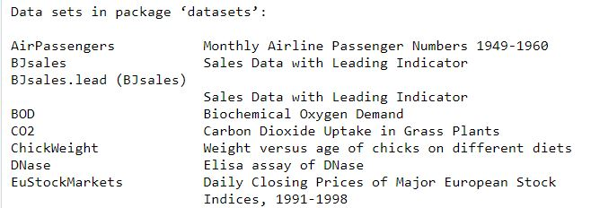

```r
# To load a built in dataset,specify its name and package
who_data = read_builtin("who", "tidyr")
```

```r
# To show columns names, datatype in each column and the values you can use
str(who_data)
```

```
## tibble [7,240 × 60] (S3: tbl_df/tbl/data.frame)
##  $ country     : chr [1:7240] "Afghanistan" "Afghanistan" "Afghanistan" "Afghanistan" ...
##  $ iso2        : chr [1:7240] "AF" "AF" "AF" "AF" ...
##  $ iso3        : chr [1:7240] "AFG" "AFG" "AFG" "AFG" ...
##  $ year        : int [1:7240] 1980 1981 1982 1983 1984 1985 1986 1987 1988 1989 ...
##  $ new_sp_m014 : int [1:7240] NA NA NA NA NA NA NA NA NA NA ...
##  $ new_sp_m1524: int [1:7240] NA NA NA NA NA NA NA NA NA NA ...
##  $ new_sp_m2534: int [1:7240] NA NA NA NA NA NA NA NA NA NA ...
##  $ new_sp_m3544: int [1:7240] NA NA NA NA NA NA NA NA NA NA ...
##  $ new_sp_m4554: int [1:7240] NA NA NA NA NA NA NA NA NA NA ...
##  $ new_sp_m5564: int [1:7240] NA NA NA NA NA NA NA NA NA NA ...
##  $ new_sp_m65  : int [1:7240] NA NA NA NA NA NA NA NA NA NA ...
##  $ new_sp_f014 : int [1:7240] NA NA NA NA NA NA NA NA NA NA ...
##  $ new_sp_f1524: int [1:7240] NA NA NA NA NA NA NA NA NA NA ...
##  $ new_sp_f2534: int [1:7240] NA NA NA NA NA NA NA NA NA NA ...
```

[output cut: 46 more lines]

```r
# Or
glimpse(who_data)
```

```
## Rows: 7,240
## Columns: 60
## $ country      <chr> "Afghanistan", "Afghanistan", "Afghanistan", "Afghanistan…
## $ iso2         <chr> "AF", "AF", "AF", "AF", "AF", "AF", "AF", "AF", "AF", "AF…
## $ iso3         <chr> "AFG", "AFG", "AFG", "AFG", "AFG", "AFG", "AFG", "AFG", "…
## $ year         <int> 1980, 1981, 1982, 1983, 1984, 1985, 1986, 1987, 1988, 198…
## $ new_sp_m014  <int> NA, NA, NA, NA, NA, NA, NA, NA, NA, NA, NA, NA, NA, NA, N…
## $ new_sp_m1524 <int> NA, NA, NA, NA, NA, NA, NA, NA, NA, NA, NA, NA, NA, NA, N…
## $ new_sp_m2534 <int> NA, NA, NA, NA, NA, NA, NA, NA, NA, NA, NA, NA, NA, NA, N…
## $ new_sp_m3544 <int> NA, NA, NA, NA, NA, NA, NA, NA, NA, NA, NA, NA, NA, NA, N…
## $ new_sp_m4554 <int> NA, NA, NA, NA, NA, NA, NA, NA, NA, NA, NA, NA, NA, NA, N…
## $ new_sp_m5564 <int> NA, NA, NA, NA, NA, NA, NA, NA, NA, NA, NA, NA, NA, NA, N…
## $ new_sp_m65   <int> NA, NA, NA, NA, NA, NA, NA, NA, NA, NA, NA, NA, NA, NA, N…
## $ new_sp_f014  <int> NA, NA, NA, NA, NA, NA, NA, NA, NA, NA, NA, NA, NA, NA, N…
## $ new_sp_f1524 <int> NA, NA, NA, NA, NA, NA, NA, NA, NA, NA, NA, NA, NA, NA, N…
```

[output cut: 47 more lines]

```r
# To show only the number and names of the datasets columns
print(colnames(who_data))
```

```
##  [1] "country"      "iso2"         "iso3"         "year"         "new_sp_m014"
##  [6] "new_sp_m1524" "new_sp_m2534" "new_sp_m3544" "new_sp_m4554" "new_sp_m5564"
## [11] "new_sp_m65"   "new_sp_f014"  "new_sp_f1524" "new_sp_f2534" "new_sp_f3544"
## [16] "new_sp_f4554" "new_sp_f5564" "new_sp_f65"   "new_sn_m014"  "new_sn_m1524"
## [21] "new_sn_m2534" "new_sn_m3544" "new_sn_m4554" "new_sn_m5564" "new_sn_m65"
## [26] "new_sn_f014"  "new_sn_f1524" "new_sn_f2534" "new_sn_f3544" "new_sn_f4554"
## [31] "new_sn_f5564" "new_sn_f65"   "new_ep_m014"  "new_ep_m1524" "new_ep_m2534"
## [36] "new_ep_m3544" "new_ep_m4554" "new_ep_m5564" "new_ep_m65"   "new_ep_f014"
## [41] "new_ep_f1524" "new_ep_f2534" "new_ep_f3544" "new_ep_f4554" "new_ep_f5564"
## [46] "new_ep_f65"   "newrel_m014"  "newrel_m1524" "newrel_m2534" "newrel_m3544"
## [51] "newrel_m4554" "newrel_m5564" "newrel_m65"   "newrel_f014"  "newrel_f1524"
## [56] "newrel_f2534" "newrel_f3544" "newrel_f4554" "newrel_f5564" "newrel_f65"
```

```r
# To rename a column(s)
# Either temporarily
rename(who_data, sp_m1524 = new_sp_m1524)
```

```
## # A tibble: 7,240 × 60
##    country     iso2  iso3   year new_sp_m014 sp_m1524 new_sp_m2534 new_sp_m3544
##    <chr>       <chr> <chr> <int>       <int>    <int>        <int>        <int>
##  1 Afghanistan AF    AFG    1980          NA       NA           NA           NA
##  2 Afghanistan AF    AFG    1981          NA       NA           NA           NA
##  3 Afghanistan AF    AFG    1982          NA       NA           NA           NA
##  4 Afghanistan AF    AFG    1983          NA       NA           NA           NA
##  5 Afghanistan AF    AFG    1984          NA       NA           NA           NA
##  6 Afghanistan AF    AFG    1985          NA       NA           NA           NA
##  7 Afghanistan AF    AFG    1986          NA       NA           NA           NA
##  8 Afghanistan AF    AFG    1987          NA       NA           NA           NA
##  9 Afghanistan AF    AFG    1988          NA       NA           NA           NA
## 10 Afghanistan AF    AFG    1989          NA       NA           NA           NA
## # … with 7,230 more rows, and 52 more variables: new_sp_m4554 <int>,
## #   new_sp_m5564 <int>, new_sp_m65 <int>, new_sp_f014 <int>,
## #   new_sp_f1524 <int>, new_sp_f2534 <int>, new_sp_f3544 <int>,
## #   new_sp_f4554 <int>, new_sp_f5564 <int>, new_sp_f65 <int>,
## #   new_sn_m014 <int>, new_sn_m1524 <int>, new_sn_m2534 <int>,
## #   new_sn_m3544 <int>, new_sn_m4554 <int>, new_sn_m5564 <int>,
## #   new_sn_m65 <int>, new_sn_f014 <int>, new_sn_f1524 <int>, …
```

```r
# Or permanently
who_data = rename(who_data, sp_m1524 = new_sp_m1524, iso = iso2)
```

```r
# We may also use summarize() to show summary statistics
# You'll learn more about pipes (%>%) later in this notebook
who_data %>%
  summarise(
    latest_year = max(year, na.rm = TRUE),
    average_sp = mean(c(new_sp_f5564, new_sp_f65, new_sn_m014), na.rm = TRUE)
  )
```

```
## # A tibble: 1 × 2
##   latest_year average_sp
##         <int>      <dbl>
## 1        2013       300.
```

*Always set `na.rm = TRUE` to remove the null values during calculation and avoid getting NA in the results.*

```r
# To load a dataset either from the web or by uploading it
# Note that each file may contain only one sheet and be in the CSV format
world_happiness = read_csv(
                    "World_Happiness_data.csv",
                    show_col_types = FALSE
                  )
world_happiness
```

```
## # A tibble: 470 × 14
##    Country   `Year of Year` Region Year  `Dystopia Resi…` `Economy (GDP …` F4
##    <chr>              <dbl> <chr>  <chr>            <dbl>            <dbl> <lgl>
##  1 Switzerl…           2015 Weste… 1/1/…             2.52              1.4 NA
##  2 Iceland             2015 Weste… 1/1/…             2.70              1.3 NA
##  3 Denmark             2015 Weste… 1/1/…             2.49              1.3 NA
##  4 Norway              2015 Weste… 1/1/…             2.47              1.5 NA
##  5 Canada              2015 North… 1/1/…             2.45              1.3 NA
##  6 Finland             2015 Weste… 1/1/…             2.62              1.3 NA
##  7 Netherla…           2015 Weste… 1/1/…             2.47              1.3 NA
##  8 Sweden              2015 Weste… 1/1/…             2.37              1.3 NA
##  9 New Zeal…           2015 Austr… 1/1/…             2.26              1.3 NA
## 10 Australia           2015 Austr… 1/1/…             2.27              1.3 NA
## # … with 460 more rows, and 7 more variables: Family <dbl>, Freedom <dbl>,
## #   Generosity <dbl>, `Happiness Rank` <dbl>, `Happiness Score` <dbl>,
## #   `Health (Life Expectancy)` <dbl>, `Trust (Government Corruption)` <dbl>
```

```r
# To view the list of sheets for an excel file
excel_sheets("CO2 Dataset.xlsx")
```

```
## [1] "About"                    "CO2 (kt) Pivoted"
## [3] "CO2 (kt) RAW DATA"        "CO2 Data Cleaned"
## [5] "CO2 (kt) for Split"       "CO2 for World to Union"
## [7] "CO2 Per Capita RAW DATA"  "CO2 Per Capita (Pivoted)"
## [9] "Metadata - Countries"
```

```r
# Paste the file path and the sheet name
co2_df = read_excel(
           "CO2 Dataset.xlsx",
           sheet = "CO2 Data Cleaned"
         )
```

```r
# We may create new directories and new files as follows
# If they're created successfully, TRUE will appear in the code output
dir.create("trial_dir")
dir.create("new_dir")
file.create("new_file.csv")
```

```
## [1] TRUE
```

```r
# We may create matrices using the matrix() function provided the elements and
# the number of rows or the number of cols
matrix_a = matrix(c(3:14), nrow = 4)
matrix_b = matrix(c(20:31), nrow = 3)
```

```r
# For matrices multiplication, use the (%*%) operator
# The number of columns of the first one must equal the number of rows of the
# second
matrix_c = matrix_b %*% matrix_a
```

*Check out this link to know more about [operators and conditions](https://drive.google.com/file/d/1b7ZeDWQJ0IU9WhOMRmTpcDc6LCqX5Qr7/view?usp=sharing)*

```r
# First check the simple examples below
x = 5
x > 3 & x < 8
```

```
## [1] TRUE
```

```r
x > 7 & x == 5  # TRUE & FALSE = FALSE
```

```
## [1] FALSE
```

```r
x > 5 | x == 3  # | is the same as ||
```

```
## [1] FALSE
```

```r
x != 8
```

```
## [1] TRUE
```

```r
y = 0
!y # As y equals zero, not zero is TRUE
```

```
## [1] TRUE
```

```r
# Now if we have a multiple values/elements
price <- c(100, 20, 5, 200, 60, 88, 190, 33, 290, 64)
price > 50
```

```
##  [1]  TRUE FALSE FALSE  TRUE  TRUE  TRUE  TRUE FALSE  TRUE  TRUE
```

```r
x = c(12, 15, 20)
y = c(13, 16, 34)

# In case of element-wise logical operators, each single element will be checked
x & y < 15
```

```
## [1]  TRUE FALSE FALSE
```

```r
# In the other case, the first element only will be checked
x && y < 15
```

```
## [1] TRUE
```

```r
# A quick note regarding arithmatic operators (%%) and (%/%)
7 %% 3
```

```
## [1] 1
```

```r
7 %/% 3
```

```
## [1] 2
```

```r
# If we wanna choose a variable name that's a reserved word (TRUE, in, etc.) or
# starts with an (_), we must use backticks (` `) to avoid getting errors.
`TRUE` = 18
`_x01` = 21
`TRUE`
```

```
## [1] 18
```

```r
`_x01`
```

```
## [1] 21
```

```r
# (<<-) is an assigment operator that's mainly used in functions.
# For instance if we wanna change change the global value of a variable inside a
# function as follows.
x <- 1
y <- 3
fun_3 <- function() {
          x <- 2
          y <<- 5
          print(paste(x, y))
}

fun_3()
```

```
## [1] "2 5"
```

```r
x # (the value hasn't changed)
```

```
## [1] 1
```

```r
y # (the value has changed)
```

```
## [1] 5
```

```r
# To access functions of a pacakge use the (::) operators
# Enter the package name then (::) and press tab to view the list of functions
lubridate::.__C__Interval
```

```
## Class "Interval" [package "lubridate"]
##
## Slots:
##
## Name:      .Data     start     tzone
## Class:   numeric   POSIXct character
##
## Extends:
## Class "Timespan", directly
## Class "numeric", from data part
## Class "vector", by class "numeric", distance 2
```

```r
# We may filter a dataframe based on logical condtion(s) using the filter() function
filter(who_data, country == c("Afghanistan",'Albania') & year > 1990)
```

```
## # A tibble: 23 × 60
##    country     iso   iso3   year new_sp_m014 sp_m1524 new_sp_m2534 new_sp_m3544
##    <chr>       <chr> <chr> <int>       <int>    <int>        <int>        <int>
##  1 Afghanistan AF    AFG    1992          NA       NA           NA           NA
##  2 Afghanistan AF    AFG    1994          NA       NA           NA           NA
##  3 Afghanistan AF    AFG    1996          NA       NA           NA           NA
##  4 Afghanistan AF    AFG    1998          30      129          128           90
##  5 Afghanistan AF    AFG    2000          52      228          183          149
##  6 Afghanistan AF    AFG    2002          90      476          481          368
##  7 Afghanistan AF    AFG    2004         139      537          568          360
##  8 Afghanistan AF    AFG    2006         193      837          791          574
##  9 Afghanistan AF    AFG    2008         187      941          773          545
## 10 Afghanistan AF    AFG    2010         197      986          819          491
## # … with 13 more rows, and 52 more variables: new_sp_m4554 <int>,
## #   new_sp_m5564 <int>, new_sp_m65 <int>, new_sp_f014 <int>,
## #   new_sp_f1524 <int>, new_sp_f2534 <int>, new_sp_f3544 <int>,
## #   new_sp_f4554 <int>, new_sp_f5564 <int>, new_sp_f65 <int>,
## #   new_sn_m014 <int>, new_sn_m1524 <int>, new_sn_m2534 <int>,
## #   new_sn_m3544 <int>, new_sn_m4554 <int>, new_sn_m5564 <int>,
## #   new_sn_m65 <int>, new_sn_f014 <int>, new_sn_f1524 <int>, …
```

```r
# Let's see an example of how the if,else and else if can be used in R
# Note the code syntax. To make sure you fully get it try to apply some changes
# and see the results
# & and | should never be used inside of an if clause because they can return
# vectors. Always use && and || instead.
if (who_data[100,]['country'] %in%
  c('China','Afghanistan','SaudiArabia')) {
  print("Asian Country")
} else if (who_data[100,]['country'] == 'Algeria') {
  print("African Country")
} else {
  print("European Country")
}
```

```
## [1] "African Country"
```

```r
# To show the unique values of a column
print(unique(who_data['country']))
```

```
## # A tibble: 219 × 1
##    country
##    <chr>
##  1 Afghanistan
##  2 Albania
##  3 Algeria
##  4 American Samoa
##  5 Andorra
##  6 Angola
##  7 Anguilla
##  8 Antigua and Barbuda
##  9 Argentina
## 10 Armenia
## # … with 209 more rows
```